# ANALYSIS OF FACTORS IMPACTING THE SLEEP PROBLEM USING LOGISTIC REGRESSION

# 1. INTRODUCTION

# 1.1 Research Question

This analysis is concerned to identify which all factors predict the likelihood that a person is facing problem in getting sleep or not? For this analysis the predictors used are - age group,weight of a person,feeling restless and quality of sleep of a person.

# 1.2 Proposed Hyothesis

1.Building a proposed model to test the hypothesis that whether problem getting in sleep can be predicted by age group, weight, restless and quality of sleep factors.

2.Building a proposed model to test the hypothesis that whether problem getting in sleep can be predicted by age group, weight, restless factors.

```r
#load the libraries needed

library(AutoModel)
library(Epi)
library(rcompanion)
library(stargazer)
```

```r
library(foreign)
library(pander)
library(ggplot2)
library(pastecs)
library(magrittr)
library(dplyr)
sleepdata <- read.csv("sleep5ED.csv")

#Check your proportions for bias - are these representative?
table(sleepdata$getsleprec)
```

```
##
##   0   1
## 163 106
```

# 1.4 Data Description

```r
nrow(sleepdata)
```

```
## [1] 271
```

```r
ncol(sleepdata)
```

```
## [1] 55
```

```r
str(sleepdata)
```

```
## 'data.frame':    271 obs. of  55 variables:
##  $ ï..id       : int  83 294 425 64 536 57 251 255 265 290 ...
##  $ sex         : int  0 0 1 0 0 0 0 0 1 1 ...
##  $ age         : int  42 54 NA 41 39 66 36 35 NA 41 ...
##  $ marital     : int  2 2 2 2 2 2 1 2 2 2 ...
##  $ edlevel     : int  2 5 2 5 5 4 3 5 5 5 ...
##  $ weight      : num  52 65 89 66 62 62 62 75 90 75 ...
##  $ height      : num  162 174 170 178 160 165 165 174 180 187 ...
##  $ healthrate  : int  10 8 6 9 9 8 9 6 6 9 ...
##  $ fitrate     : int  7 7 5 7 5 8 7 6 6 9 ...
##  $ weightrate  : int  5 5 7 5 7 5 7 8 8 3 ...
##  $ smoke       : int  1 2 2 1 2 2 2 2 2 1 ...
##  $ smokenum    : num  15 NA NA 5 NA NA NA NA NA 7 ...
##  $ alchohol    : num  3 0 12 2 1 1 0 2 0.25 1 ...
##  $ caffeine    : num  5 10 4 3 6 3 3 3 2 3 ...
```

[output cut: 41 more lines]

# 2. Methodology

## 2.1 Variables of interest

The variables of interest used in this research are shown below:

```r
panderOptions('table.split.table', Inf)

my.data <- "
  Concept                       | Variable Name     | Statistical Type        | Possible Values

Problem Getting sleep           | getsleprec        | Categorical             | 0=no;1=yes

Weight                          | weight            | Scale                   |

Age Group                       | agegp3            | Categorical             |1=<=37yrs;                                                                           2=38-50yrs;3=51+yrs

Restless                        | restlss           | Categorical             |1=yes;2=no
Quality of Sleep                | qualsleeprec      | ordinal             |1=very poor,                                                                         poor 2=fair, 3=good,
                                                                      4=very good, excellent"
df <- read.delim(textConnection(my.data),header=FALSE,sep="|",strip.white=TRUE,stringsAsFactors=FALSE)
names(df) <- unname(as.list(df[1,])) # put headers on
df <- df[-1,] # remove first row
row.names(df)<-NULL
pander(df, style = 'rmarkdown')
```

| Concept | Variable Name | Statistical Type | Possible Values |
| --- | --- | --- | --- |
| Problem Getting sleep | getsleprec | Categorical | 0=no;1=yes |
| Weight | weight | Scale |  |
| Age Group | agegp3 | Categorical | 1=<=37yrs; 2=38-50yrs;3=51+yrs |
| Restless | restlss | Categorical | 1=yes;2=no |
| Quality of Sleep | qualsleeprec | ordinal | 1=very poor, poor 2=fair, 3=good, |
| 4=very good, excellent |  |  |  |

# 3 DATA ANALYSIS

# 3.1 PROBLEM GETTING SLEEP

Problem Getting Sleep (getsleprec) variable in the sleep data set is a categorical variable.This is the recoded variable and is grouped into two categories as ‘No’ for 0 and ‘Yes’ for 1. ###Code for inspecting the variable

```r
table(sleepdata$getsleprec)
```

```
##
##   0   1
## 163 106
```

```r
#Statistical summary of problem getting sleep variable
summary(sleepdata$getsleprec)
```

```
##    Min. 1st Qu.  Median    Mean 3rd Qu.    Max.    NA's
##  0.0000  0.0000  0.0000  0.3941  1.0000  1.0000       2
```

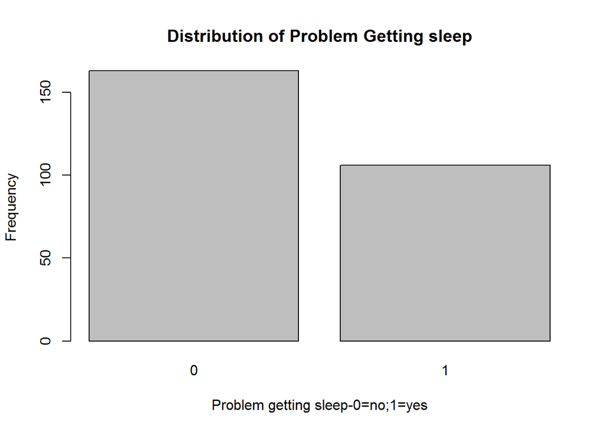

```r
getsleprecFreq<- table(sleepdata$getsleprec)
barplot(getsleprecFreq,xlab = "Problem getting sleep-0=no;1=yes",ylab = "Frequency",main = "Distribution of Problem Getting sleep")
```

# 3.2 AGE GROUP RECODED INTO 3 GROUPS

Age Group (agegp3) variable in the sleep data set is a categorical variable.The age is grouped into three categories - when age is <= 37 then group 1,when age is between 38-50 then group 2 and finally when age is equal to 51 and 51+ are in group 3. ###Code for inspecting the variable

```r
table(sleepdata$agegp3)
```

```
##
##  1  2  3
## 83 86 79
```

```r
#Get descriptive statistics by group
psych::describeBy(sleepdata$getsleprec, sleepdata$agegp3)
```

```
##
##  Descriptive statistics by group
## group: 1
##    vars  n mean  sd median trimmed mad min max range  skew kurtosis   se
## X1    1 82 0.54 0.5      1    0.55   0   0   1     1 -0.14       -2 0.06
## --------------------------------------------------------
## group: 2
##    vars  n mean   sd median trimmed mad min max range skew kurtosis   se
## X1    1 85 0.31 0.46      0    0.26   0   0   1     1 0.83    -1.33 0.05
## --------------------------------------------------------
## group: 3
##    vars  n mean   sd median trimmed mad min max range skew kurtosis   se
## X1    1 79 0.29 0.46      0    0.25   0   0   1     1  0.9     -1.2 0.05
```

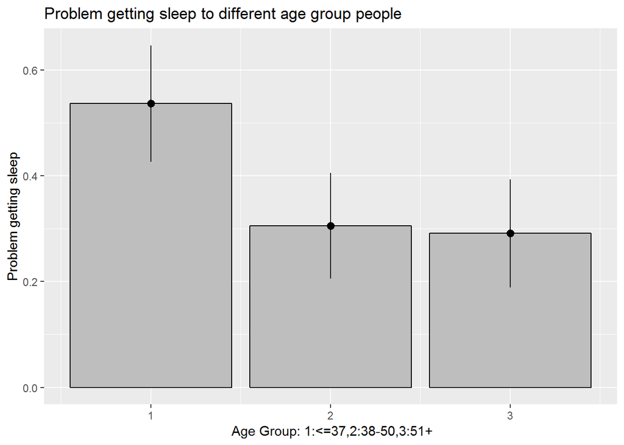

```r
bar <- ggplot(sleepdata, aes(agegp3, getsleprec))
bar + stat_summary(fun.y = mean, geom = "bar", fill = "Grey", colour = "Black") + stat_summary(fun.data = mean_cl_normal, geom = "pointrange") + labs(x = " Age Group: 1:<=37,2:38-50,3:51+", y = "Problem getting sleep", title="Problem getting sleep to different age group people")
```

# 3.3 WEIGHT

### Code for inspecting the variable

```r
#Descriptive statistics
pastecs::stat.desc(sleepdata$weight, basic=F)
```

```
##       median         mean      SE.mean CI.mean.0.95          var
##   72.0000000   73.3837349    0.9685962    1.9077235  233.6064783
##      std.dev     coef.var
##   15.2841905    0.2082776
```

```r
#skewness and kurtosis from semTools with standard error
tpskew<-semTools::skew(sleepdata$weight)
tpkurt<-semTools::kurtosis(sleepdata$weight)
#We divide the skew statistic by the standard error to get the standardised score
stdskew<-tpskew[1]/tpskew[2]
stdkurt<-tpkurt[1]/tpkurt[2]
stdskew
```

```
## skew (g1)
##  6.498358
```

```r
stdkurt
```

```
## Excess Kur (g2)
##        11.18265
```

```r
tpskew
```

```
##    skew (g1)           se            z            p
## 1.008741e+00 1.552301e-01 6.498358e+00 8.120149e-11
```

```r
tpkurt
```

```
## Excess Kur (g2)              se               z               p
##       3.4717674       0.3104602      11.1826486       0.0000000
```

```r
#Use dplyr filter to filter out the rows with a standardised value outside the range
outliers <- sleepdata %>%
  filter(scale(weight) >3.29 | scale(weight) < -3.29)

#count them using dplyr summarize
numoutliers<-outliers %>%
  summarize(count=n())
fullcount<-sleepdata %>%
  summarize(count=n())

numoutliers
```

```
##   count
## 1     1
```

```r
fullcount
```

```
##   count
## 1   271
```

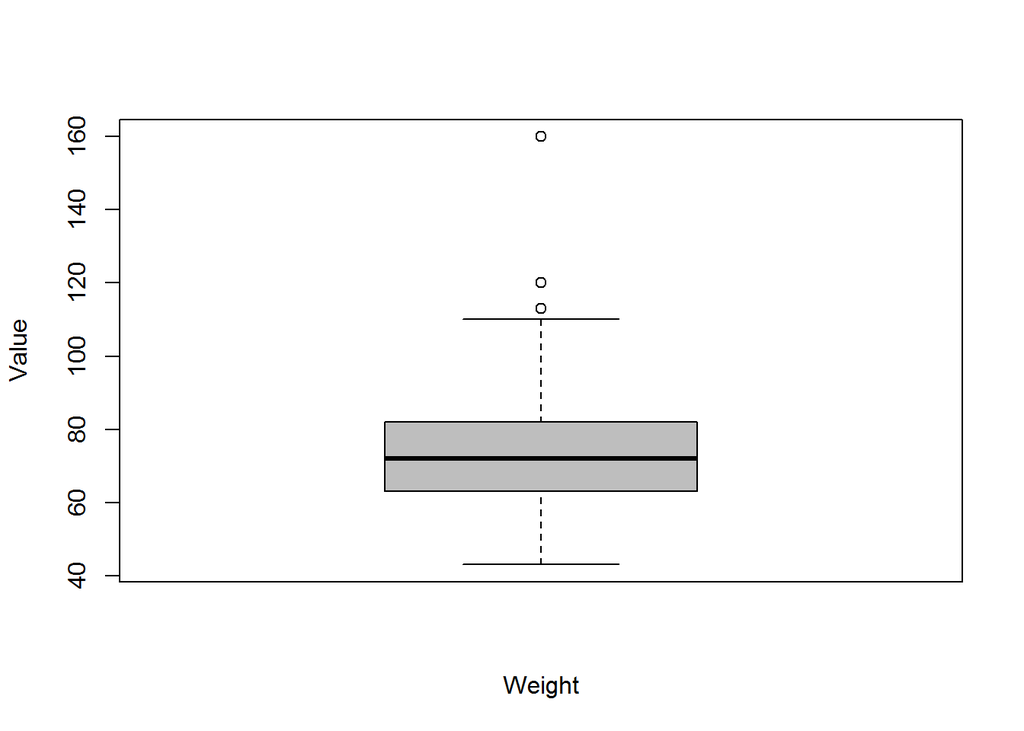

```r
boxplot(sleepdata$weight,xlab = "Weight",ylab = "Value",col = "grey")
```

```r
#Removing Outliers
outliers<-boxplot(sleepdata$weight,plot = FALSE)$out
print(outliers)
```

```
## [1] 120 160 113
```

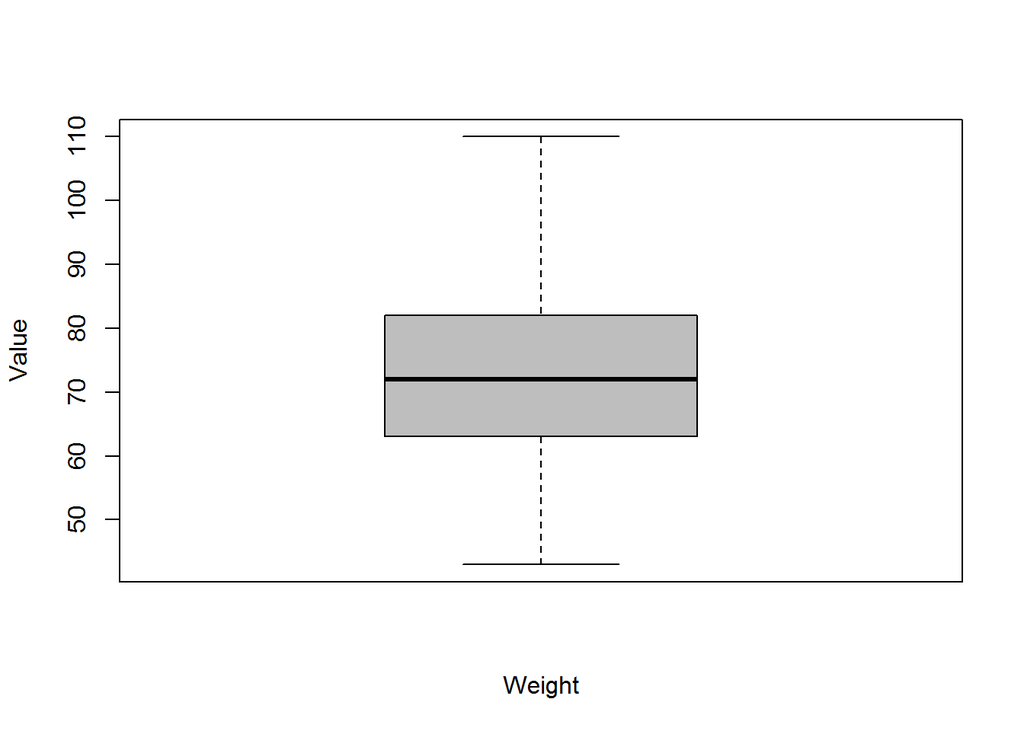

```r
sleepdata<- sleepdata[-which(sleepdata$weight %in% outliers),]
boxplot(sleepdata$weight,xlab = "Weight",ylab = "Value",col = "grey")
```

Inspection of normal scores for skewness and kurtosis indicated that while skewness was not an issue falling with an acceptable range of +/-2, (skewness of 1.0087407 SE=0.1552301), kurtosis was outside acceptable bounds, (kurtosis of 3.4717674 SE=0.3104602 .

In statistics outlier is an observation that is very different from the other data points. The outliers have a significant effect on the mean and standard deviation. Box plot is useful to detect the outliers in the variable. For the weight variable the outliers were present which were removed to get the statistically precise output.

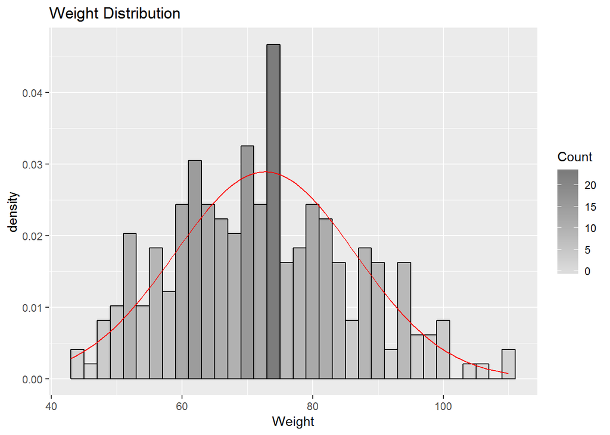

```r
#Create a histogram
gg<- ggplot(sleepdata,aes(x=sleepdata$weight))
#Change the label of x-axis
gg<- gg+labs(x="Weight")
#manage binwidth and colours
gg <- gg + geom_histogram(binwidth=2, colour="black", aes(y=..density.., fill=..count..))
gg <- gg + scale_fill_gradient("Count", low="#DCDCDC", high="#7C7C7C")
#Adding a normal curve using stat_function
gg <- gg + stat_function(fun=dnorm, color="red",args=list(mean=mean(sleepdata$weight, na.rm=TRUE), sd=sd(sleepdata$weight, na.rm=TRUE)))

gg<-gg+ggtitle('Weight Distribution')

#To display the graph
gg
```

# 3.4 RESTLESS

### Code for inspecting the variable

```r
table(sleepdata$restlss)
```

```
##
##   1   2
##  87 175
```

```r
#Get descriptive statistics by group
psych::describeBy(sleepdata$getsleprec, sleepdata$restlss)
```

```
##
##  Descriptive statistics by group
## group: 1
##    vars  n mean  sd median trimmed mad min max range  skew kurtosis   se
## X1    1 87 0.53 0.5      1    0.54   0   0   1     1 -0.11    -2.01 0.05
## --------------------------------------------------------
## group: 2
##    vars   n mean   sd median trimmed mad min max range skew kurtosis   se
## X1    1 173 0.34 0.47      0    0.29   0   0   1     1 0.69    -1.53 0.04
```

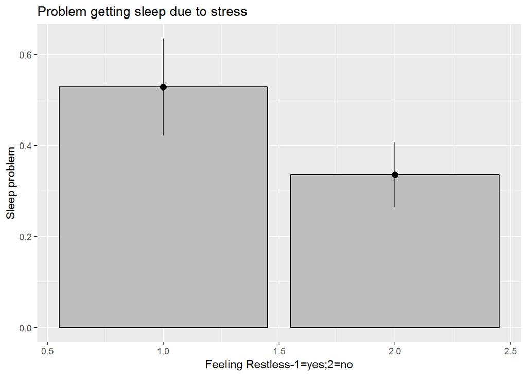

```r
bar <- ggplot(sleepdata, aes(restlss, getsleprec))
bar + stat_summary(fun.y = mean, geom = "bar", fill = "Grey", colour = "Black") + stat_summary(fun.data = mean_cl_normal, geom = "pointrange") + labs(x = "Feeling Restless-1=yes;2=no", y = "Sleep problem", title="Problem getting sleep due to stress")
```

# 3.4 QUALITY OF SLEEP

This is an ordinal variable which is a type of categorical variable used as a predictor to analyze our hypothesis of getting problem in sleep.Sleep Quality is 1=very poor, poor 2=fair, 3=good,4=very good, excellent. ###Code for inspecting the variable

```r
table(sleepdata$qualsleeprec)
```

```
##
##  1  2  3  4
## 36 73 89 67
```

```r
#Get descriptive statistics by group
psych::describeBy(sleepdata$getsleprec, sleepdata$qualsleeprec)
```

```
##
##  Descriptive statistics by group
## group: 1
##    vars  n mean   sd median trimmed mad min max range  skew kurtosis   se
## X1    1 36 0.69 0.47      1    0.73   0   0   1     1 -0.81    -1.38 0.08
## --------------------------------------------------------
## group: 2
##    vars  n mean  sd median trimmed mad min max range skew kurtosis   se
## X1    1 73 0.47 0.5      0    0.46   0   0   1     1 0.13    -2.01 0.06
## --------------------------------------------------------
## group: 3
##    vars  n mean   sd median trimmed mad min max range skew kurtosis   se
## X1    1 88  0.4 0.49      0    0.38   0   0   1     1 0.41    -1.85 0.05
## --------------------------------------------------------
## group: 4
##    vars  n mean   sd median trimmed mad min max range skew kurtosis   se
## X1    1 66 0.17 0.38      0    0.09   0   0   1     1 1.75     1.07 0.05
```

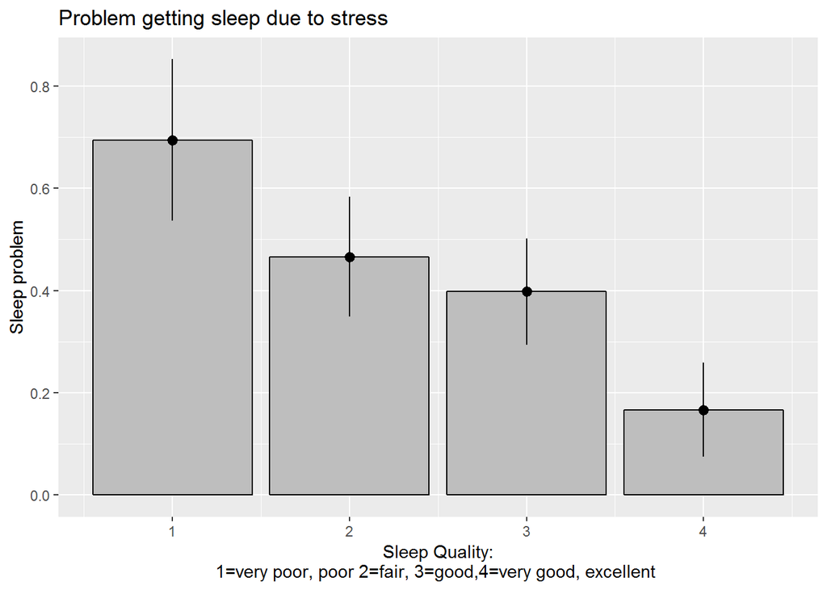

```r
bar <- ggplot(sleepdata, aes(qualsleeprec, getsleprec))
bar + stat_summary(fun.y = mean, geom = "bar", fill = "Grey", colour = "Black") + stat_summary(fun.data = mean_cl_normal, geom = "pointrange") + labs(x = "Sleep Quality:
1=very poor, poor 2=fair, 3=good,4=very good, excellent ", y = "Sleep problem", title="Problem getting sleep due to stress")
```

# 4 DATA PREPARATION

Data preparation is the process of cleaning data before performing statistical analysis.It is used to find the awkward data such as missing values or outliers and to remove them.

# 4.1 HANDLING MISSING VALUES

When no data value is recorded for any variable then that is called as missing values. These missing values are denoted by ‘NA’. The function is.na() function in R is used to find the missing values in R for each variable. Here in the outcome variable ‘problem in getting sleep’ 2 NA values are present. Likewise in all the predictor variables few NA values are present which are removed. In this case firstly only those variables required for statistical analysis were fetched and stored in a new data frame then for continuous predictor variable ‘Weight’ the missing values are imputed by the average value and then lastly all the NA values for categorical variables are removed using na.omit() R function. As the missing values can reduce the calculated statistics precision and make the result misleading. So missing value transformations are performed.

```r
sum(is.na(sleepdata$getsleprec))
```

```
## [1] 2
```

```r
sum(is.na(sleepdata$weight))
```

```
## [1] 22
```

```r
#Imputing the missing values in weight column by the average value
avgweight<- mean(sleepdata$weight,na.rm = TRUE)
avgweight<- round(avgweight)
avgweight
```

```
## [1] 73
```

```r
sleepdata$weight[is.na(sleepdata$weight)]<-avgweight
View(sleepdata$weight)

sum(is.na(sleepdata$agegp3))
```

```
## [1] 23
```

```r
sum(is.na(sleepdata$restlss))
```

```
## [1] 6
```

```r
View(sleepdata)
#Removing few variables

sleepdf<- sleepdata[,c(6,37,49,50,53)]
View(sleepdf)
#Now removing all NA from dataset
sleepdf<-na.omit(sleepdf)
View(sleepdf)
```

# 4.2 Checking the Difference and correlation between variables

```r
#Difference between getsleprec and agegp3
library(gmodels)
CrossTable(sleepdf$agegp3, sleepdf$getsleprec, fisher = TRUE, chisq = TRUE, expected = TRUE)
```

```
##
##
##    Cell Contents
## |-------------------------|
## |                       N |
## |              Expected N |
## | Chi-square contribution |
## |           N / Row Total |
## |           N / Col Total |
## |         N / Table Total |
## |-------------------------|
##
##
## Total Observations in Table:  235
##
##
##                | sleepdf$getsleprec
## sleepdf$agegp3 |         0 |         1 | Row Total |
## ---------------|-----------|-----------|-----------|
##              1 |        37 |        42 |        79 |
##                |    48.409 |    30.591 |           |
##                |     2.689 |     4.255 |           |
##                |     0.468 |     0.532 |     0.336 |
##                |     0.257 |     0.462 |           |
##                |     0.157 |     0.179 |           |
## ---------------|-----------|-----------|-----------|
##              2 |        57 |        26 |        83 |
##                |    50.860 |    32.140 |           |
##                |     0.741 |     1.173 |           |
##                |     0.687 |     0.313 |     0.353 |
##                |     0.396 |     0.286 |           |
##                |     0.243 |     0.111 |           |
## ---------------|-----------|-----------|-----------|
##              3 |        50 |        23 |        73 |
##                |    44.732 |    28.268 |           |
##                |     0.620 |     0.982 |           |
##                |     0.685 |     0.315 |     0.311 |
##                |     0.347 |     0.253 |           |
##                |     0.213 |     0.098 |           |
## ---------------|-----------|-----------|-----------|
##   Column Total |       144 |        91 |       235 |
##                |     0.613 |     0.387 |           |
## ---------------|-----------|-----------|-----------|
##
##
## Statistics for All Table Factors
##
##
## Pearson's Chi-squared test
## ------------------------------------------------------------
## Chi^2 =  10.45992     d.f. =  2     p =  0.005353742
##
##
##
## Fisher's Exact Test for Count Data
## ------------------------------------------------------------
## Alternative hypothesis: two.sided
## p =  0.005712903
##
##
```

```r
#Correlationn between getsleprec and weight
cor.test(sleepdf$weight,sleepdf$getsleprec,method = "spearman")
```

```
##
##  Spearman's rank correlation rho
##
## data:  sleepdf$weight and sleepdf$getsleprec
## S = 2299700, p-value = 0.3345
## alternative hypothesis: true rho is not equal to 0
## sample estimates:
##         rho
## -0.06322718
```

```r
#Difference between getsleprec and restless
CrossTable(sleepdf$restlss, sleepdf$getsleprec, fisher = TRUE, chisq = TRUE, expected = TRUE)
```

```
##
##
##    Cell Contents
## |-------------------------|
## |                       N |
## |              Expected N |
## | Chi-square contribution |
## |           N / Row Total |
## |           N / Col Total |
## |         N / Table Total |
## |-------------------------|
##
##
## Total Observations in Table:  235
##
##
##                 | sleepdf$getsleprec
## sleepdf$restlss |         0 |         1 | Row Total |
## ----------------|-----------|-----------|-----------|
##               1 |        40 |        37 |        77 |
##                 |    47.183 |    29.817 |           |
##                 |     1.094 |     1.730 |           |
##                 |     0.519 |     0.481 |     0.328 |
##                 |     0.278 |     0.407 |           |
##                 |     0.170 |     0.157 |           |
## ----------------|-----------|-----------|-----------|
##               2 |       104 |        54 |       158 |
##                 |    96.817 |    61.183 |           |
##                 |     0.533 |     0.843 |           |
##                 |     0.658 |     0.342 |     0.672 |
##                 |     0.722 |     0.593 |           |
##                 |     0.443 |     0.230 |           |
## ----------------|-----------|-----------|-----------|
##    Column Total |       144 |        91 |       235 |
##                 |     0.613 |     0.387 |           |
## ----------------|-----------|-----------|-----------|
##
##
## Statistics for All Table Factors
##
```

[output cut: 13 more lines]

```
##
## Alternative hypothesis: true odds ratio is not equal to 1
## p =  0.04634793
## 95% confidence interval:  0.3107275 1.01703
##
## Alternative hypothesis: true odds ratio is less than 1
## p =  0.02870758
## 95% confidence interval:  0 0.9305311
##
## Alternative hypothesis: true odds ratio is greater than 1
## p =  0.9854873
## 95% confidence interval:  0.3398676 Inf
##
##
##
```

```r
#Difference between getsleprec and qualsleeprec
CrossTable(sleepdf$qualsleeprec, sleepdf$getsleprec, fisher = TRUE, chisq = TRUE, expected = TRUE)
```

```
##
##
##    Cell Contents
## |-------------------------|
## |                       N |
## |              Expected N |
## | Chi-square contribution |
## |           N / Row Total |
## |           N / Col Total |
## |         N / Table Total |
## |-------------------------|
##
##
## Total Observations in Table:  235
##
##
##                      | sleepdf$getsleprec
## sleepdf$qualsleeprec |         0 |         1 | Row Total |
## ---------------------|-----------|-----------|-----------|
##                    1 |        10 |        19 |        29 |
##                      |    17.770 |    11.230 |           |
##                      |     3.398 |     5.376 |           |
##                      |     0.345 |     0.655 |     0.123 |
##                      |     0.069 |     0.209 |           |
##                      |     0.043 |     0.081 |           |
## ---------------------|-----------|-----------|-----------|
##                    2 |        36 |        30 |        66 |
##                      |    40.443 |    25.557 |           |
##                      |     0.488 |     0.772 |           |
##                      |     0.545 |     0.455 |     0.281 |
##                      |     0.250 |     0.330 |           |
##                      |     0.153 |     0.128 |           |
## ---------------------|-----------|-----------|-----------|
##                    3 |        50 |        33 |        83 |
##                      |    50.860 |    32.140 |           |
##                      |     0.015 |     0.023 |           |
##                      |     0.602 |     0.398 |     0.353 |
##                      |     0.347 |     0.363 |           |
##                      |     0.213 |     0.140 |           |
## ---------------------|-----------|-----------|-----------|
```

[output cut: 12 more lines]

```
## Statistics for All Table Factors
##
##
## Pearson's Chi-squared test
## ------------------------------------------------------------
## Chi^2 =  22.70646     d.f. =  3     p =  4.649088e-05
##
##
##
## Fisher's Exact Test for Count Data
## ------------------------------------------------------------
## Alternative hypothesis: two.sided
## p =  2.703651e-05
##
##
```

# 4.3 Multicollinearity

Multicollinearity is a phenomena in which one predictor variable in a regression model is correlated to the other predictor variable with a substantial degree of accuracy. In this the correlation is checked between the predictor variables and the outcome variable by creating a correlation matrix method (Lines 263-265). As with the given variables all correlation values are found less than 0.8 so this means that no multicollinearity is found.

```r
mycorr<- cor(sleepdf)
mycorr
```

```
##                   weight    restlss  getsleprec qualsleeprec     agegp3
## weight        1.00000000 -0.1281791 -0.07866839  -0.08078373  0.1400771
## restlss      -0.12817914  1.0000000 -0.13368928   0.38470595 -0.0334520
## getsleprec   -0.07866839 -0.1336893  1.00000000  -0.29851271 -0.1812327
## qualsleeprec -0.08078373  0.3847060 -0.29851271   1.00000000 -0.1899544
## agegp3        0.14007707 -0.0334520 -0.18123270  -0.18995435  1.0000000
```

```r
round(mycorr, 2)
```

```
##              weight restlss getsleprec qualsleeprec agegp3
## weight         1.00   -0.13      -0.08        -0.08   0.14
## restlss       -0.13    1.00      -0.13         0.38  -0.03
## getsleprec    -0.08   -0.13       1.00        -0.30  -0.18
## qualsleeprec  -0.08    0.38      -0.30         1.00  -0.19
## agegp3         0.14   -0.03      -0.18        -0.19   1.00
```

# 5.Logistic Regression

The Logistic Regression is a statistical model used to predict a categorical variable as an outcome variable from one or more categorical or continuous predictor variables. In this prediction model binary logistic regression is used where the dependent variable is coded as 0 = No and 1 = Yes. The logistic regression equation from which the probability of outcome variable Y is predicted is given by: P(Y) = 1/(1+e^-(b0+b1X1))

Where P(Y) is the probability of occurring Y, e is the base of natural logarithms, b0 is the constant,X1 is the predictor and b1 is the coefficient of X1.When there are several predictors the equation becomes: P(Y) = 1/(1+e^-(b0+b1X1+b2X2+….+bnXn))

### Build baseline model with age group and weight as predictors

### Model 1

A binomial logistic regression was calculated to predict a person’s problem in getting sleep based on the categorical variable age group and a continuous variable weight of a person. The stargazer function is used to get the summary of the log model with co-efficient.

```r
#Make sure categorical data is used as factors

logmodel1 <- glm(getsleprec ~ agegp3+weight, data = sleepdf, na.action = na.exclude, family = binomial(link = logit))

#Summary of the model with co-efficients
stargazer(logmodel1, type="text")
```

```
##
## =============================================
##                       Dependent variable:
##                   ---------------------------
##                           getsleprec
## ---------------------------------------------
## agegp3                     -0.455***
##                             (0.173)
##
## weight                      -0.009
##                             (0.010)
##
## Constant                     1.060
##                             (0.796)
##
## ---------------------------------------------
## Observations                  235
## Log Likelihood             -152.600
## Akaike Inf. Crit.           311.200
## =============================================
## Note:             *p<0.1; **p<0.05; ***p<0.01
```

```r
#Full summary of the model
summary(logmodel1)
```

```
##
## Call:
## glm(formula = getsleprec ~ agegp3 + weight, family = binomial(link = logit),
##     data = sleepdf, na.action = na.exclude)
##
## Deviance Residuals:
##     Min       1Q   Median       3Q      Max
## -1.2740  -0.9978  -0.8005   1.2120   1.7093
##
## Coefficients:
##              Estimate Std. Error z value Pr(>|z|)
## (Intercept)  1.059614   0.796371   1.331  0.18334
## agegp3      -0.454739   0.173415  -2.622  0.00873 **
## weight      -0.008851   0.010470  -0.845  0.39790
## ---
## Signif. codes:  0 '***' 0.001 '**' 0.01 '*' 0.05 '.' 0.1 ' ' 1
##
## (Dispersion parameter for binomial family taken to be 1)
##
##     Null deviance: 313.72  on 234  degrees of freedom
## Residual deviance: 305.20  on 232  degrees of freedom
## AIC: 311.2
##
## Number of Fisher Scoring iterations: 4
```

```r
#Chi-square plus significance
lmtest::lrtest(logmodel1)
```

```
## Likelihood ratio test
##
## Model 1: getsleprec ~ agegp3 + weight
## Model 2: getsleprec ~ 1
##   #Df  LogLik Df  Chisq Pr(>Chisq)
## 1   3 -152.60
## 2   1 -156.86 -2 8.5224    0.01411 *
## ---
## Signif. codes:  0 '***' 0.001 '**' 0.01 '*' 0.05 '.' 0.1 ' ' 1
```

```r
#Pseudo Rsquared plus Chi-square of the model
rcompanion::nagelkerke(logmodel1,restrictNobs=TRUE)
```

```
## $Models
##
## Model: "glm, getsleprec ~ agegp3 + weight, binomial(link = logit), sleepdf, na.exclude"
## Null:  "glm, getsleprec ~ 1, binomial(link = logit), fit$model, na.exclude"
##
## $Pseudo.R.squared.for.model.vs.null
##                              Pseudo.R.squared
## McFadden                            0.0271654
## Cox and Snell (ML)                  0.0356158
## Nagelkerke (Cragg and Uhler)        0.0483359
##
## $Likelihood.ratio.test
##  Df.diff LogLik.diff  Chisq  p.value
##       -2     -4.2612 8.5224 0.014105
##
## $Number.of.observations
##
## Model: 235
## Null:  235
##
## $Messages
## [1] "Note: For models fit with REML, these statistics are based on refitting with ML"
##
## $Warnings
## [1] "None"
```

```r
#Exponentiate the co-efficients
exp(coefficients(logmodel1))
```

```
## (Intercept)      agegp3      weight
##   2.8852563   0.6346133   0.9911879
```

```r
#Calculate confusion matrix
AutoModel::classification_table(logmodel1, sleepdf$getsleprec)
```

```
##        Actual
## Predict   0   1
##       0 128  76
##       1  16  15
## Specificity:  0.483871
## Sensitivity:  0.627451
## Total Accuracy:  0.6085106
```

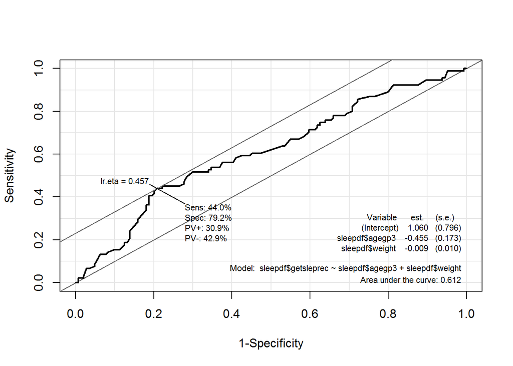

```r
#Output the sensitivity, specificity, and ROC plot

Epi::ROC(form=sleepdf$getsleprec ~ sleepdf$agegp3+sleepdf$weight, plot="ROC")
```

```r
#Chi-square and Pseudo R2 calculation for information
modelChi <- logmodel1$null.deviance - logmodel1$deviance
modelChi
```

```
## [1] 8.522385
```

```r
pseudo.R2 <- modelChi / logmodel1$null.deviance
pseudo.R2
```

```
## [1] 0.02716536
```

```r
Chidf <- logmodel1$df.null - logmodel1$df.residual
Chidf
```

```
## [1] 2
```

```r
chisq.prob <- 1 - pchisq(modelChi, Chidf)
chisq.prob
```

```
## [1] 0.01410547
```

The summary(logmodel1) function is used to get the summary of the complete model with Deviance residuals and coefficients details. Deviance Residuals, are a measure of model fit which is used as a part of the calculation of Chi-square. The residual deviance is calculated as 305.20 on 232 degrees of freedom whereas the Null deviance is calculated as 313.72 on 234 degrees of freedom. At this stage of analysis the value of deviance should be less than the value for the Null model because lower the value the model is said to be more accurate to predict the outcome variable (Field Miles). Due to some intervention the value is reduced. A Chi-square significance plus test is performed to predict how better the model can predict the outcome variable. Here the value is significant at a 0.05 level and so we can say that overall the model is predicting whether a person is getting problem to sleep or not significantly better. Degree of freedom is calculated as 2 in the model which shows the number of variables in the model. Also here the Chi- square probability is calculated which is ‘chisq.prob <- 1 - pchisq(modelChi, Chidf)’ 0.014 which is less than 0.05 which is statistically significant(p<0.05) that means the model is better in predicting the outcome. Here ??2(2) = 8.52, p = 0.014. The agegp3 predictor is statistially significant in predicting the output. A confusion matrix is calculated for the baseline model which calculated the Specificity, Sensitivity and Accuracy of the model. Here in this model Total observations n= 235 out of which 128+15=143 were predicted correctly and 76+16 =92 were wrongly predicted. Specificity: 0.483871 Sensitivity: 0.627451 Total Accuracy: 0.6085106 The Sensitivity of the model tells the percentage of people saying ‘yes’. In this case the model was able to identify 62.7% of the people who said they have problem in getting sleep. The Specificity of the model tells the percentage of people saying ‘no’. In this case the model was able to identify 48.4% of the people who said they do not have problem in getting sleep. PV+ is 30.9% which is calculated by dividing the number of predicted cases as Yes/the total number predicted. PV- is 42.9% which is calculated by dividing the number of predicted cases as no/the total number predicted. AUC the Area Under Curve is literally just the percentage of this graph that is under the curve. Here the AUC is 0.612 which is in between 0.5 and 0.8(Andy Field) Tests to see if the data met the assumption of collinearity indicated that multicollinearity was not a concern (AgeGroup, VIF= 1.01; Weight, VIF= 1.01) and were within acceptable levels (VIF <2.5) (Tarling (2008)).The tolerance of the model predictor that is the reciprocal of VIF was calculated which was not a concern (AgeGroup, 1/VIF= 0.99; Weight, 1/VIF= 0.99) and were within acceptable range(Tolerance >0.4) (Tarling (2008)).

### Building Second model adding Restless variable

A binomial logistic regression was calculated to predict a person’s problem in getting sleep based on the categorical variable age group ,continuous variable weight of a person and a categorical variable Restless Sleeper.

```r
#Second model adding Restless variable
logmodel2 <- glm(getsleprec ~ agegp3+weight+restlss, data = sleepdf, na.action = na.exclude, family = binomial(link = logit))
#Summary of the model with co-efficients
stargazer(logmodel2, type="text")
```

```
##
## =============================================
##                       Dependent variable:
##                   ---------------------------
##                           getsleprec
## ---------------------------------------------
## agegp3                     -0.470***
##                             (0.175)
##
## weight                      -0.012
##                             (0.011)
##
## restlss                    -0.673**
##                             (0.294)
##
## Constant                    2.453**
##                             (1.021)
##
## ---------------------------------------------
## Observations                  235
## Log Likelihood             -149.960
## Akaike Inf. Crit.           307.921
## =============================================
## Note:             *p<0.1; **p<0.05; ***p<0.01
```

```r
#Full summary of the model
summary(logmodel2)
```

```
##
## Call:
## glm(formula = getsleprec ~ agegp3 + weight + restlss, family = binomial(link = logit),
##     data = sleepdf, na.action = na.exclude)
##
## Deviance Residuals:
##     Min       1Q   Median       3Q      Max
## -1.5224  -0.9729  -0.7660   1.2422   1.8035
##
## Coefficients:
##             Estimate Std. Error z value Pr(>|z|)
## (Intercept)  2.45280    1.02084   2.403  0.01627 *
## agegp3      -0.46992    0.17526  -2.681  0.00733 **
## weight      -0.01226    0.01072  -1.144  0.25262
## restlss     -0.67330    0.29409  -2.289  0.02205 *
## ---
## Signif. codes:  0 '***' 0.001 '**' 0.01 '*' 0.05 '.' 0.1 ' ' 1
##
## (Dispersion parameter for binomial family taken to be 1)
##
##     Null deviance: 313.72  on 234  degrees of freedom
## Residual deviance: 299.92  on 231  degrees of freedom
## AIC: 307.92
##
## Number of Fisher Scoring iterations: 4
```

```r
#Chi-square plus significance
lmtest::lrtest(logmodel2)
```

```
## Likelihood ratio test
##
## Model 1: getsleprec ~ agegp3 + weight + restlss
## Model 2: getsleprec ~ 1
##   #Df  LogLik Df  Chisq Pr(>Chisq)
## 1   4 -149.96
## 2   1 -156.86 -3 13.802   0.003188 **
## ---
## Signif. codes:  0 '***' 0.001 '**' 0.01 '*' 0.05 '.' 0.1 ' ' 1
```

```r
#Pseudo Rsquared plus Chi-square of the model
rcompanion::nagelkerke(logmodel2,restrictNobs=TRUE)
```

```
## $Models
##
## Model: "glm, getsleprec ~ agegp3 + weight + restlss, binomial(link = logit), sleepdf, na.exclude"
## Null:  "glm, getsleprec ~ 1, binomial(link = logit), fit$model, na.exclude"
##
## $Pseudo.R.squared.for.model.vs.null
##                              Pseudo.R.squared
## McFadden                            0.0439939
## Cox and Snell (ML)                  0.0570400
## Nagelkerke (Cragg and Uhler)        0.0774118
##
## $Likelihood.ratio.test
##  Df.diff LogLik.diff  Chisq   p.value
##       -3     -6.9009 13.802 0.0031876
##
## $Number.of.observations
##
## Model: 235
## Null:  235
##
## $Messages
## [1] "Note: For models fit with REML, these statistics are based on refitting with ML"
##
## $Warnings
## [1] "None"
```

```r
#Exponentiate the co-efficients
exp(coefficients(logmodel2))
```

```
## (Intercept)      agegp3      weight     restlss
##  11.6208823   0.6250522   0.9878110   0.5100237
```

```r
#Calculate confusion matrix
AutoModel::classification_table(logmodel2, sleepdf$getsleprec)
```

```
##        Actual
## Predict   0   1
##       0 117  59
##       1  27  32
## Specificity:  0.5423729
## Sensitivity:  0.6647727
## Total Accuracy:  0.6340426
```

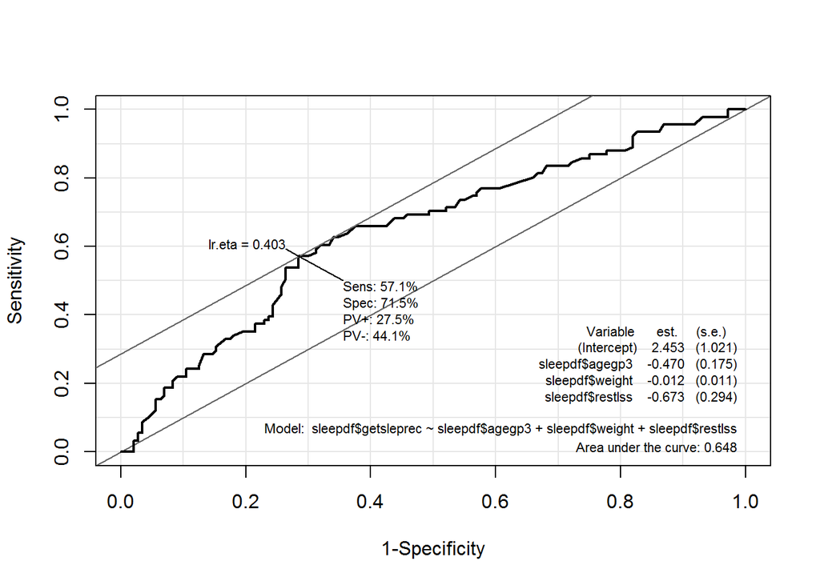

```r
#Output the sensitivity, specificity, and ROC plot
Epi::ROC(form=sleepdf$getsleprec ~ sleepdf$agegp3+sleepdf$weight+sleepdf$restlss, plot="ROC")
```

```r
#Chi-square and Pseudo R2 calculation for information
modelChi <- logmodel2$null.deviance - logmodel2$deviance
modelChi
```

```
## [1] 13.80189
```

```r
pseudo.R2 <- modelChi / logmodel2$null.deviance
pseudo.R2
```

```
## [1] 0.04399395
```

```r
Chidf <- logmodel2$df.null - logmodel2$df.residual
Chidf
```

```
## [1] 3
```

```r
chisq.prob <- 1 - pchisq(modelChi, Chidf)
chisq.prob
```

```
## [1] 0.003187598
```

The stargazer function is used to get the summary of the log model with co-efficient.The summary(logmodel2) function is used to get the summary of the complete model with Deviance residuals and coefficients details. Deviance Residuals, are a measure of model fit which is used as a part of the calculation of Chi-square. The residual deviance is calculated as 299.92 on 231 degrees of freedom whereas the Null deviance is calculated as 313.72 on 234 degrees of freedom. At this stage of analysis the value of deviance should be less than the value for the Null model because lower the value the model is said to be more accurate to predict the outcome variable (Field Miles). Due to some intervention the value is reduced.

### Building Third model adding Quality of Sleep variable

A binomial logistic regression was calculated to predict a person’s problem in getting sleep based on the categorical variable age group ,continuous variable weight of a person ,a categorical variable Restless Sleeper and anordinal variable Quality of Sleep.

```r
#Third model adding Restless variable
logmodel3 <- glm(getsleprec ~ agegp3+weight+restlss+qualsleeprec, data = sleepdf, na.action = na.exclude, family = binomial(link = logit))
#Summary of the model with co-efficients
stargazer(logmodel3, type="text")
```

```
##
## =============================================
##                       Dependent variable:
##                   ---------------------------
##                           getsleprec
## ---------------------------------------------
## agegp3                     -0.719***
##                             (0.197)
##
## weight                      -0.015
##                             (0.011)
##
## restlss                     -0.084
##                             (0.332)
##
## qualsleeprec               -0.846***
##                             (0.182)
##
## Constant                   4.364***
##                             (1.177)
##
## ---------------------------------------------
## Observations                  235
## Log Likelihood             -137.378
## Akaike Inf. Crit.           284.756
## =============================================
## Note:             *p<0.1; **p<0.05; ***p<0.01
```

```r
#Full summary of the model
summary(logmodel3)
```

```
##
## Call:
## glm(formula = getsleprec ~ agegp3 + weight + restlss + qualsleeprec,
##     family = binomial(link = logit), data = sleepdf, na.action = na.exclude)
##
## Deviance Residuals:
##     Min       1Q   Median       3Q      Max
## -1.9820  -0.8975  -0.5809   1.1215   1.9827
##
## Coefficients:
##              Estimate Std. Error z value Pr(>|z|)
## (Intercept)   4.36353    1.17708   3.707 0.000210 ***
## agegp3       -0.71943    0.19736  -3.645 0.000267 ***
## weight       -0.01459    0.01145  -1.275 0.202467
## restlss      -0.08385    0.33246  -0.252 0.800871
## qualsleeprec -0.84646    0.18193  -4.653 3.28e-06 ***
## ---
## Signif. codes:  0 '***' 0.001 '**' 0.01 '*' 0.05 '.' 0.1 ' ' 1
##
## (Dispersion parameter for binomial family taken to be 1)
##
##     Null deviance: 313.72  on 234  degrees of freedom
## Residual deviance: 274.76  on 230  degrees of freedom
## AIC: 284.76
##
## Number of Fisher Scoring iterations: 3
```

```r
#Chi-square plus significance
lmtest::lrtest(logmodel3)
```

```
## Likelihood ratio test
##
## Model 1: getsleprec ~ agegp3 + weight + restlss + qualsleeprec
## Model 2: getsleprec ~ 1
##   #Df  LogLik Df  Chisq Pr(>Chisq)
## 1   5 -137.38
## 2   1 -156.86 -4 38.966   7.08e-08 ***
## ---
## Signif. codes:  0 '***' 0.001 '**' 0.01 '*' 0.05 '.' 0.1 ' ' 1
```

```r
#Pseudo Rsquared plus Chi-square of the model
rcompanion::nagelkerke(logmodel3,restrictNobs=TRUE)
```

```
## $Models
##
## Model: "glm, getsleprec ~ agegp3 + weight + restlss + qualsleeprec, binomial(link = logit), sleepdf, na.exclude"
## Null:  "glm, getsleprec ~ 1, binomial(link = logit), fit$model, na.exclude"
##
## $Pseudo.R.squared.for.model.vs.null
##                              Pseudo.R.squared
## McFadden                             0.124205
## Cox and Snell (ML)                   0.152795
## Nagelkerke (Cragg and Uhler)         0.207366
##
## $Likelihood.ratio.test
##  Df.diff LogLik.diff  Chisq    p.value
##       -4     -19.483 38.966 7.0798e-08
##
## $Number.of.observations
##
## Model: 235
## Null:  235
##
## $Messages
## [1] "Note: For models fit with REML, these statistics are based on refitting with ML"
##
## $Warnings
## [1] "None"
```

```r
#Exponentiate the co-efficients
exp(coefficients(logmodel3))
```

```
##  (Intercept)       agegp3       weight      restlss qualsleeprec
##   78.5339839    0.4870276    0.9855186    0.9195661    0.4289313
```

```r
#Calculate confusion matrix
AutoModel::classification_table(logmodel3, sleepdf$getsleprec)
```

```
##        Actual
## Predict   0   1
##       0 106  35
##       1  38  56
## Specificity:  0.5957447
## Sensitivity:  0.751773
## Total Accuracy:  0.6893617
```

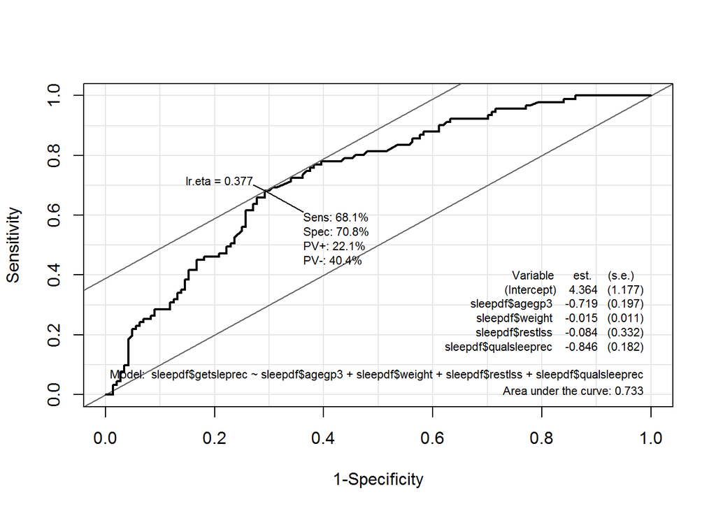

```r
#Output the sensitivity, specificity, and ROC plot
Epi::ROC(form=sleepdf$getsleprec ~ sleepdf$agegp3+sleepdf$weight+sleepdf$restlss+sleepdf$qualsleeprec, plot="ROC")
```

```r
#Chi-square and Pseudo R2 calculation for information
modelChi <- logmodel3$null.deviance - logmodel3$deviance
modelChi
```

```
## [1] 38.96605
```

```r
pseudo.R2 <- modelChi / logmodel3$null.deviance
pseudo.R2
```

```
## [1] 0.1242055
```

```r
Chidf <- logmodel3$df.null - logmodel3$df.residual
Chidf
```

```
## [1] 4
```

```r
chisq.prob <- 1 - pchisq(modelChi, Chidf)
chisq.prob
```

```
## [1] 7.07983e-08
```

The stargazer function is used to get the summary of the log model with co-efficient.The summary(logmodel3) function is used to get the summary of the complete model with Deviance residuals and coefficients details. Deviance Residuals, are a measure of model fit which is used as a part of the calculation of Chi-square. The residual deviance is calculated as 274.76 on 230 degrees of freedom whereas the Null deviance is calculated as 313.72 on 234 degrees of freedom. At this stage of analysis the value of deviance should be less than the value for the Null model because lower the value the model is said to be more accurate to predict the outcome variable (Field Miles). Due to some intervention the value is reduced.

```r
#Checking the tolerance of the models
library(car)
#Collinearity
vifmodel<-vif(logmodel1)
vifmodel
```

```
##   agegp3   weight
## 1.013202 1.013202
```

```r
#Calculate tolerance
1/vifmodel
```

```
##    agegp3    weight
## 0.9869697 0.9869697
```

```r
#Collinearity
vifmodel<-vif(logmodel2)
vifmodel
```

```
##   agegp3   weight  restlss
## 1.017334 1.036816 1.031416
```

```r
#Calculate tolerance
1/vifmodel
```

```
##    agegp3    weight   restlss
## 0.9829614 0.9644910 0.9695414
```

```r
#Collinearity
vifmodel<-vif(logmodel3)
vifmodel
```

```
##       agegp3       weight      restlss qualsleeprec
##     1.155175     1.051584     1.196276     1.337312
```

```r
#Calculate tolerance
1/vifmodel
```

```
##       agegp3       weight      restlss qualsleeprec
##    0.8656697    0.9509461    0.8359275    0.7477687
```

```r
library(sqldf)
View(sleepdf)
weight1<-sqldf("select weight, agegp3 from sleepdf where agegp3==1")
View(weight1)
avgwt1<- mean(weight1$weight,na.rm = TRUE)
avgwt1
```

```
## [1] 70.96456
```

```r
weight2<-sqldf("select weight, agegp3 from sleepdf where agegp3==2")
View(weight2)
avgwt2<- mean(weight2$weight,na.rm = TRUE)
avgwt2
```

```
## [1] 70.31687
```

# 6.Result Prediction of Models

# 7.Result and Discussion

In this analysis the outcome variable is person’s problem getting to sleep is analysed using predictor variables Age group,weight,Feeling Restlessand quality of sleep using logistic regression. Total three models are analysed by adding a new predictor each time.This is the Forward Logistic regression model.First model is tested for two predictors age group and weight.Then the next model is created by adding a new predictor restless and finally another predictor Quality of sleep variable is added.The p-value for predictor is calculated within the model to check the statistical significance of predictors.The overall accuracy of model 1 was 60.8%,model 2 was 63.4% and lastly model 3 was 68.9%.

# References

Tarling,Statistical Modelling for Social Researchers (2008)

Peck, Olsen and Devore,Statistics and Data Analysis

Field, Miles and Field,Discovering Statistics Using R

Brase and Brase,Understanding Basic Statistics,SPSS Survival Manual, Julie Pallant